# ChIP-seq analysis

Vanessa Dumeaux

# 1. Unsupervised analysis - MACS2 peaks

We conducted an unsupervised analysis of peaks computed individually for each sample by [MACS2](https://github.com/taoliu/MACS) using the DiffBind R package

Refs:

- [Stark R and Brown G (2011). DiffBind: differential binding analysis of ChIP-Seq peak data.](http://bioconductor.org/packages/release/bioc/vignettes/DiffBind/inst/doc/DiffBind.pdf)
- [Ross-Innes CS, Stark R, Teschendorff AE, Holmes KA, Ali HR, Dunning MJ, Brown GD, Gojis O, Ellis IO, Green AR, Ali S, Chin S, Palmieri C, Caldas C, Carroll JS (2012). “Differential oestrogen receptor binding is associated with clinical outcome in breast cancer.” Nature, 481,-4.](http://www.nature.com/nature/journal/v481/n7381/full/nature10730.html)

Please refer to the Diffbind R package to format `sample.diffbind` that provides paths to the peak calls from MACS2. We precomputed the DBA object to read in peaksets output from MACS2 as follow:

```r
library(GenomicRanges)
library(DiffBind)
```

```r
t30.dba <- dba(sampleSheet = sample.table[sample.diffbind$Treatment=="t30" & !sample.diffbind$Factor=="SUMO",])
t30.dba.counts <- dba.count(t30.dba)

t180.dba <- dba(sampleSheet = sample.table[sample.diffbind$Treatment=="t180" & !sample.diffbind$Factor=="SUMO",])
t180.dba.counts <- dba.count(t180.dba)

sumo.dba <- dba(sampleSheet=sample.diffbind[sample.diffbind$Factor=="SUMO",])
sumo.dba.counts <- dba.count(sumo.dba)
```

##### + PCA plot of log2-normalized counts under peaks

###### Exploratory plots of ERa peaks stratified on timepoint

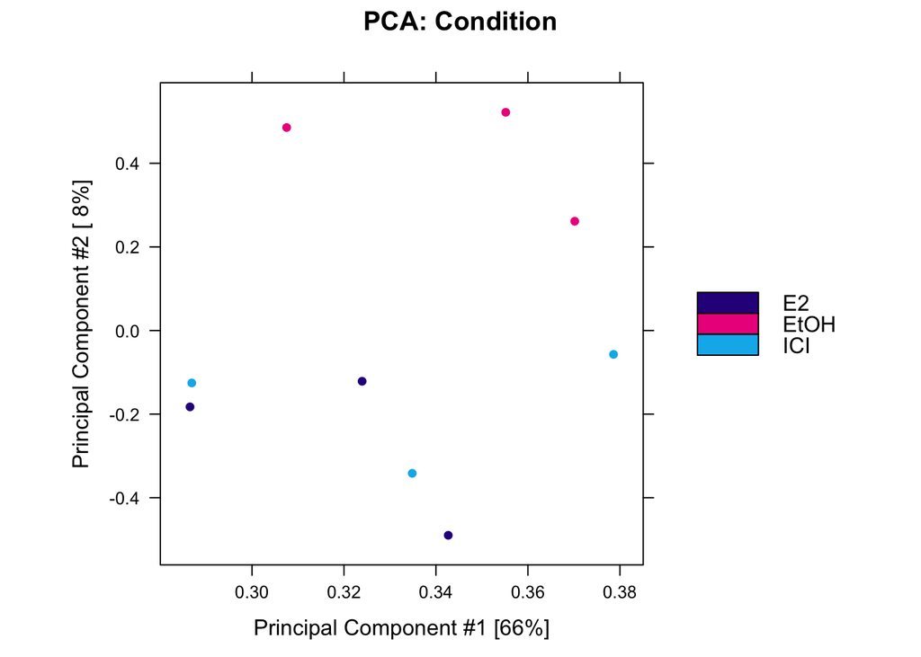

```r
t30.dba.counts <- readRDS("../data/t30.dba.counts.rds")
dba.plotPCA(t30.dba.counts,attributes = DBA_CONDITION, dotSize = 0.8)
```

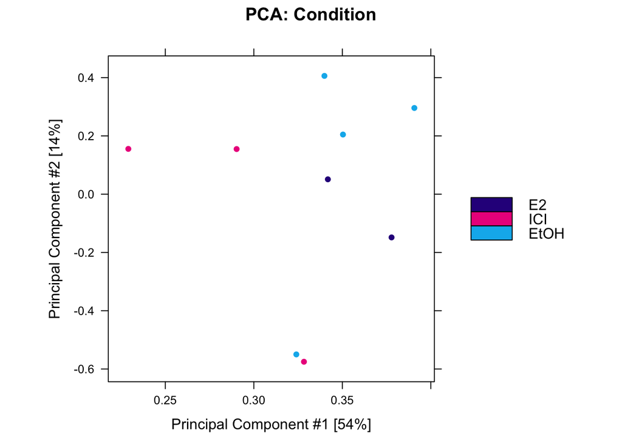

```r
t180.dba.counts <- readRDS("../data/t180.dba.counts.rds")
dba.plotPCA(t180.dba.counts,attributes = DBA_CONDITION, dotSize = 0.8)
```

###### Exploratory plot of SUMO peaks

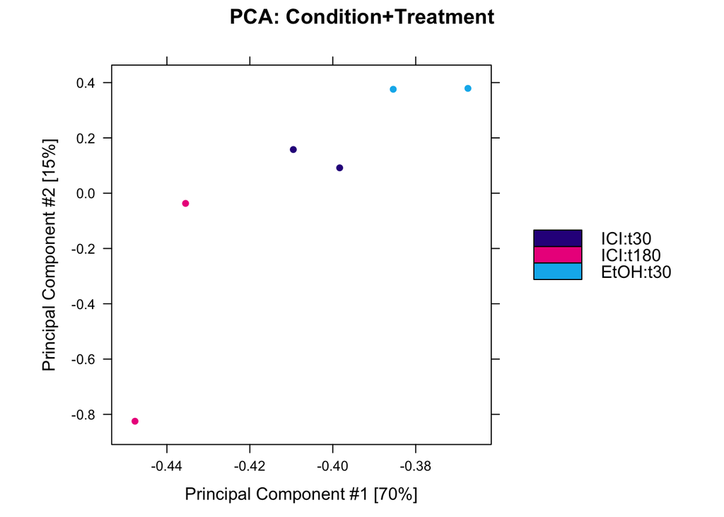

```r
sumo.dba.counts <- readRDS("../data/sumo.dba.counts.rds")
dba.plotPCA(sumo.dba.counts,attributes = c(DBA_CONDITION,DBA_TREATMENT), dotSize = 0.8)
```

# 2. ERE analysis

##### + Import ERE regions coordinates

```r
library(GenomicRanges)

ere <- read.table("../data/EREs.hg19.txt", sep = "\t",
                  header = T, stringsAsFactors = FALSE)
colnames(ere) <- ifelse(colnames(ere)=="Chrom.", "chrom", colnames(ere))
ere_hg19 <- makeGRangesFromDataFrame(ere)
```

##### + Identify ERa peaks (overlap between E2-30’ and ICI-30’) that contain ERE

```r
peaks <- read.table("../data/peaks-overlap.txt", sep="\t", header = T)
head(peaks)
```

|  | seqnames | starts | ends | names | scores | strands | pvalue..log10 | fold_enrichment | qvalue..log10 | V.30.SUMO | ICI.30.SUMO | ICI.180.SUMO |
| --- | --- | --- | --- | --- | --- | --- | --- | --- | --- | --- | --- | --- |
| 1 | chr20 | 52739412 | 52741602 | peak_call/ICI_30_peak_6983 | 45975 | * | 4607.019 | 37.98177 | 4597.523 | 1 | 1 | 1 |
| 2 | chr20 | 49378327 | 49382226 | peak_call/ICI_30_peak_6946 | 39997 | * | 4007.106 | 34.32859 | 3999.733 | 1 | 1 | 1 |
| 3 | chr20 | 46703423 | 46706624 | peak_call/ICI_30_peak_6876 | 31193 | * | 3126.299 | 46.89782 | 3119.343 | 1 | 1 | 1 |
| 4 | chr17 | 64947134 | 64949959 | peak_call/ICI_30_peak_4878 | 21286 | * | 2135.309 | 77.53243 | 2128.676 | 1 | 1 | 1 |
| 5 | chr8 | 129151988 | 129155972 | peak_call/ICI_30_peak_10976 | 20359 | * | 2042.525 | 81.77103 | 2035.936 | 1 | 1 | 0 |
| 6 | chr20 | 52277454 | 52279119 | peak_call/ICI_30_peak_6968 | 18831 | * | 1889.684 | 14.94396 | 1883.165 | 0 | 0 | 0 |

```r
peaks$idx <- 1:nrow(peaks)
dim(peaks)
```

```
[1] 11656    13
```

```r
E2ICIpeaks <- GenomicRanges::makeGRangesFromDataFrame(peaks,
                                      start.field = "starts",
                                      end.field = "ends")
E2ICIpeaks
```

```
GRanges object with 11656 ranges and 0 metadata columns:
          seqnames                 ranges strand
             <Rle>              <IRanges>  <Rle>
      [1]    chr20 [ 52739412,  52741602]      *
      [2]    chr20 [ 49378327,  49382226]      *
      [3]    chr20 [ 46703423,  46706624]      *
      [4]    chr17 [ 64947134,  64949959]      *
      [5]     chr8 [129151988, 129155972]      *
      ...      ...                    ...    ...
  [11652]     chr6   [10348252, 10348479]      *
  [11653]    chr17   [76210173, 76210389]      *
  [11654]    chr22   [25791746, 25791967]      *
  [11655]    chr16   [88374027, 88374257]      *
  [11656]    chr15   [70902175, 70902442]      *
  -------
  seqinfo: 40 sequences from an unspecified genome; no seqlengths
```

```r
rtracklayer::export.bed(E2ICIpeaks, "../data/E2ICIpeaks.bed")

olap <- findOverlaps(ere_hg19, E2ICIpeaks, type="within")
olap
```

```
Hits object with 3260 hits and 0 metadata columns:
         queryHits subjectHits
         <integer>   <integer>
     [1]        27         531
     [2]        72        4462
     [3]        73        3821
     [4]        94        1475
     [5]       128        1435
     ...       ...         ...
  [3256]    134888         693
  [3257]    134889         693
  [3258]    135430        1924
  [3259]    135431        1924
  [3260]    135436        7872
  -------
  queryLength: 136238 / subjectLength: 11656
```

```r
rtracklayer::export.bed(E2ICIpeaks[olap@to,], "../data/E2ICIpeaks-ERE.bed")
```

##### + Plot tag density heatmap using deepTools2

Trimmed and sorted bam files were normalized using [deepTools2 version 2.0](https://deeptools.readthedocs.io/en/2.0.0/content/list_of_tools.html) ( Ramírez, Fidel, Devon P. Ryan, Björn Grüning, Vivek Bhardwaj, Fabian Kilpert, Andreas S. Richter, Steffen Heyne, Friederike Dündar, and Thomas Manke. deepTools2: A next Generation Web Server for Deep-Sequencing Data Analysis. Nucleic Acids Research (2016). ) as follow:

```bash
#!/usr/bin/env bash
# File: batch-bamCoverage.sh
files=`find . -name "*.sorted.dup.bam"`

for i in $files
do
out=`basename "${i%%.sorted.dup.bam}"`
echo $out
bamCoverage -b $i -o normalizeTo1/$out.norm.bw \
--normalizeTo1x 2451960000 --maxFragmentLength 600 -p 40
done
```

`computeMatrix()` calculates scores per regions of interest (ERa peaks containing EREs) +/- 3kb and `plotHeatmap()` draws the tag density for these regions.

```bash
computeMatrix reference-point \
    -S  V_30_merged.bw E2_30_merged.bw ICI_30_merged.bw ICI_180_merged.bw \
    -R ~/repositories/mader/chipseq-ICI/data/E2ICIpeaks-ERE.bed \
    -b 3000 -a 3000 \
    -o ../../ERpeaksERE-chipER-refpoint.gz \
    --referencePoint center \
    -p 40
```

```bash
plotHeatmap -m ERpeaksERE-chipER-refpoint.gz \
    -out heatmap-E2ICIpeaks-ERE-chipER-refpoint.pdf \
    --sortUsingSamples 1 \
    --colorList 'white,blue'
```

# 3. Study SUMO binding for ChIP-seq ERa peaks

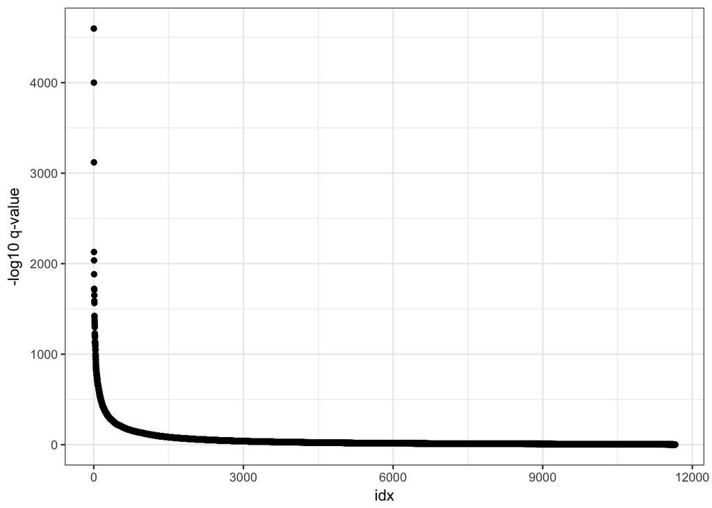

```r
library(ggplot2)

q.plot <- ggplot(peaks, aes(x = idx, y=qvalue..log10))+
  theme_bw() +
  #ggtitle("")+
  ylab("-log10 q-value")+
  geom_point()

print(q.plot)
```

```r
### show proportion of ICI-SUMO overlap by quantiles of top peaks
q <- quantile(peaks$qvalue..log10, probs = c(0.95, 0.90, 0.80, 0.50, 0.25, 0))
q
```

```
      95%       90%       80%       50%       25%        0%
192.43114 107.68133  52.94139  16.15635   8.47367   1.33150
```

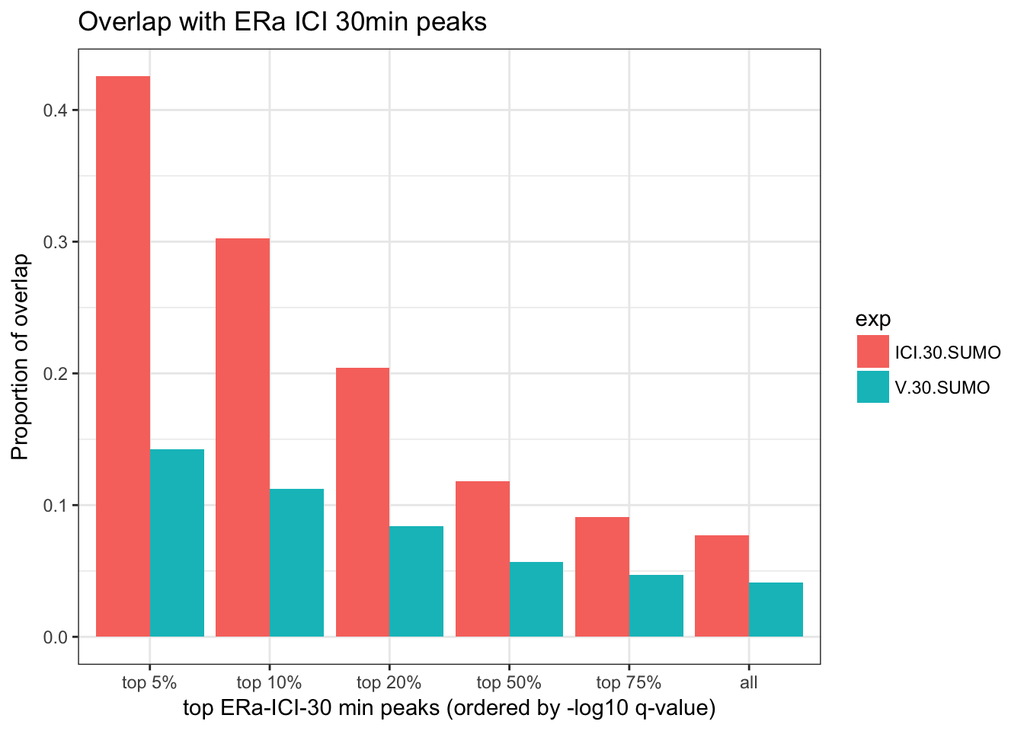

```r
peaks$ICI.30.ERa <- 1

library(limma)
a <- unlist(lapply(q, function(x){
  tab <- vennCounts(peaks[peaks$qvalue..log10 > x, colnames(peaks) %in% c("V.30.SUMO","ICI.30.ERa")])
  prop <- tab[4,3]/(tab[2,3]+tab[4,3])
  return(prop)
  }))

b <- unlist(lapply(q, function(x){
  tab <- vennCounts(peaks[peaks$qvalue..log10 > x,colnames(peaks) %in% c("ICI.30.SUMO","ICI.30.ERa")])
  prop <- tab[4,3]/(tab[2,3]+tab[4,3])
  return(prop)
  }))

prop <- c(a, b)
quant.labels <- c("top 5%", "top 10%", "top 20%", "top 50%", "top 75%", "all")
q.labels <- factor(rep(quant.labels, 2), levels=quant.labels, ordered = TRUE)
quant <- c(names(a), names(b))
exp <- c(rep("V.30.SUMO", length(a)),
         rep("ICI.30.SUMO", length(b)))
mydata <- data.frame(value = prop,
                     quant = quant,
                     q.labels = q.labels,
                     exp = exp)

p <-ggplot(mydata, aes(q.labels, value))+
  geom_bar(stat = "identity", aes(fill = exp), position = "dodge") +
  xlab("top ERa-ICI-30 min peaks (ordered by -log10 q-value)") + ylab("Proportion of overlap") +
  ggtitle("Overlap with ERa ICI 30min peaks") +
  theme_bw()

p
```

##### + Select top 5% ERa peaks and draw normalized tag density heatmaps in SUMO experiments

```r
top.ERa.peaks <- peaks[peaks$qvalue..log10 > q[1], ]

top.ERa.peaks <- GenomicRanges::makeGRangesFromDataFrame(top.ERa.peaks,
                                      start.field = "starts",
                                      end.field = "ends")
top.ERa.peaks
```

```
GRanges object with 583 ranges and 0 metadata columns:
        seqnames                 ranges strand
           <Rle>              <IRanges>  <Rle>
    [1]    chr20 [ 52739412,  52741602]      *
    [2]    chr20 [ 49378327,  49382226]      *
    [3]    chr20 [ 46703423,  46706624]      *
    [4]    chr17 [ 64947134,  64949959]      *
    [5]     chr8 [129151988, 129155972]      *
    ...      ...                    ...    ...
  [579]     chr4   [ 6281913,  6282530]      *
  [580]     chr5   [55324991, 55326491]      *
  [581]    chr18   [37102817, 37104083]      *
  [582]    chr10   [ 1015978,  1017053]      *
  [583]    chr22   [29214478, 29216297]      *
  -------
  seqinfo: 40 sequences from an unspecified genome; no seqlengths
```

```r
rtracklayer::export.bed(top.ERa.peaks, "../data/top-ERa-peaks.bed")
```

##### + Plot tag density heatmap using deepTools2

```bash
computeMatrix reference-point \
    -S V_30_SUMO_merged.bw ICI_30_SUMO_merged.bw ICI_180_SUMO_merged.bw \
    -R ~/repositories/mader/chipseq-ICI/data/sel.coord.bed \
    -b 3000 -a 3000 \
    -o ../../topERpeaks-chipSUMO-refpoint.gz \
    --referencePoint center \
    -p 40
```

```bash
plotHeatmap -m topERpeaks-chipSUMO-refpoint.gz \
    -out heatmap-topERpeaks-chipSUMO-refpoint.pdf \
    --sortUsingSamples 1 \
    --colorList 'white,blue'
```

# 4. Reproducibility of SUMO binding for topER peaks

We used `multiBigwigSummary` from deepTools2 to compute the average scores for each ChIP-seq SUMO sample for the top 5% ERa peaks.

```bash
multiBigwigSummary BED-file -b V_30_SUMO_N1.norm.bw V_30_SUMO_N2.norm.bw ICI_30_SUMO_N1.norm.bw ICI_30_SUMO_N2.norm.bw ICI_3h_SUMO_N1.norm.bw ICI_3h_SUMO_N2.norm.bw \
-out topERpeaks-allSUMO-compare.npz \
--BED ../../data/top-ERa-peaks --outRawCounts ~/Downloads/topERpeaks-allSUMO-compare.tab
```

We them imported and plotted the results using ggplot2 R package.

```r
corr2 <- read.table("~/Downloads/topERpeaks-allSUMO-compare.tab", sep="\t")
colnames(corr2) <- c("seqnames", "start", "end", "V_30_SUMO_N1", "V_30_SUMO_N2",
                    "ICI_30_SUMO_N1", "ICI_30_SUMO_N2", "ICI_3h_SUMO_N1", "ICI_3h_SUMO_N2")
head(corr2)
```

|  | seqnames | start | end | V_30_SUMO_N1 | V_30_SUMO_N2 | ICI_30_SUMO_N1 | ICI_30_SUMO_N2 | ICI_3h_SUMO_N1 | ICI_3h_SUMO_N2 |
| --- | --- | --- | --- | --- | --- | --- | --- | --- | --- |
| 1 | chr16 | 79070887 | 79072365 | 2.213643 | 2.432675 | 3.370692 | 2.843111 | 2.863233 | 2.375661 |
| 2 | chr16 | 85338622 | 85340907 | 1.611430 | 1.391483 | 3.705930 | 1.985439 | 2.796764 | 2.405931 |
| 3 | chr16 | 85498002 | 85500969 | 3.189419 | 1.898676 | 4.649461 | 3.143996 | 2.897390 | 2.529035 |
| 4 | chr16 | 85553991 | 85555431 | 5.791465 | 4.272805 | 6.096531 | 4.098564 | 3.541659 | 2.731360 |
| 5 | chr16 | 85779437 | 85780999 | 3.701719 | 3.038085 | 5.185016 | 3.510047 | 3.206018 | 3.138272 |
| 6 | chr16 | 86226545 | 86229100 | 2.605546 | 1.639128 | 2.384159 | 2.107226 | 2.200768 | 1.719145 |

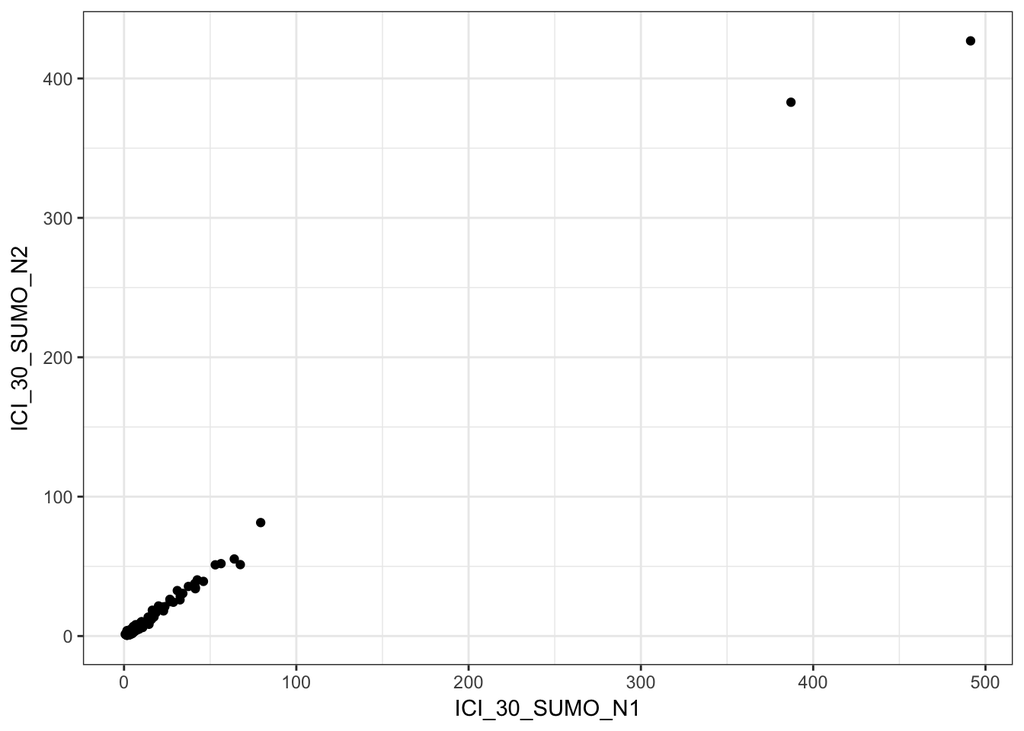

```r
p <- ggplot(corr2, aes(x=ICI_30_SUMO_N1, y=ICI_30_SUMO_N2)) +
  geom_point() +
  theme_bw()
p
```

```r
cor.test(corr2$ICI_30_SUMO_N1, corr2$ICI_30_SUMO_N2, method="spearman")
```

```
    Spearman's rank correlation rho

data:  corr2$ICI_30_SUMO_N1 and corr2$ICI_30_SUMO_N2
S = 5596300, p-value < 2.2e-16
alternative hypothesis: true rho is not equal to 0
sample estimates:
      rho
0.8305473
```

```r
cor.test(corr2$ICI_30_SUMO_N1, corr2$ICI_30_SUMO_N2)
```

```
    Pearson's product-moment correlation

data:  corr2$ICI_30_SUMO_N1 and corr2$ICI_30_SUMO_N2
t = 313.62, df = 581, p-value < 2.2e-16
alternative hypothesis: true correlation is not equal to 0
95 percent confidence interval:
 0.9965406 0.9975006
sample estimates:
      cor
0.9970595
```

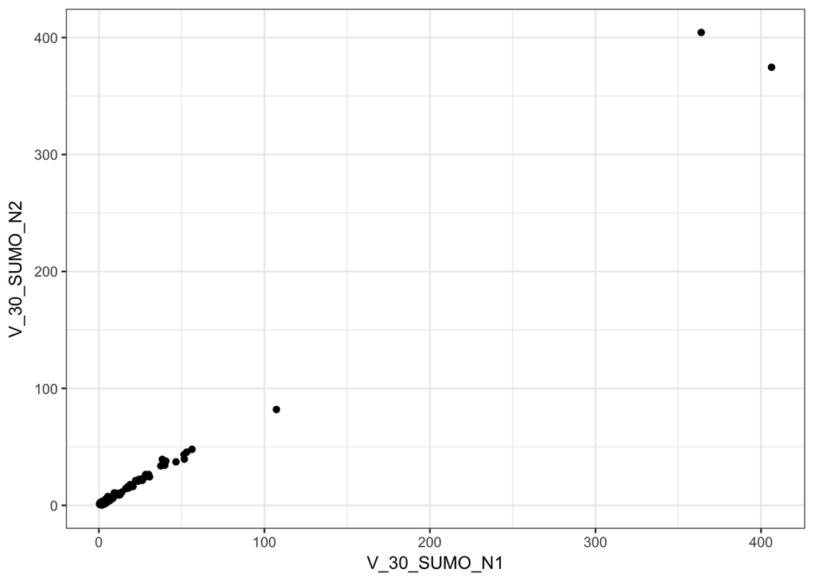

```r
p <- ggplot(corr2, aes(x=V_30_SUMO_N1, y=V_30_SUMO_N2)) +
  geom_point() +
  theme_bw()
p
```

```r
cor.test(corr2$V_30_SUMO_N1, corr2$V_30_SUMO_N2, method="spearman")
```

```
    Spearman's rank correlation rho

data:  corr2$V_30_SUMO_N1 and corr2$V_30_SUMO_N2
S = 5180600, p-value < 2.2e-16
alternative hypothesis: true rho is not equal to 0
sample estimates:
      rho
0.8431362
```

```r
cor.test(corr2$V_30_SUMO_N1, corr2$V_30_SUMO_N2)
```

```
    Pearson's product-moment correlation

data:  corr2$V_30_SUMO_N1 and corr2$V_30_SUMO_N2
t = 214.47, df = 581, p-value < 2.2e-16
alternative hypothesis: true correlation is not equal to 0
95 percent confidence interval:
 0.9926419 0.9946809
sample estimates:
      cor
0.9937437
```

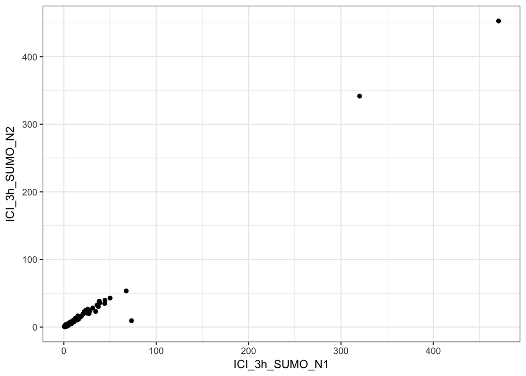

```r
p <- ggplot(corr2, aes(x=ICI_3h_SUMO_N1, y=ICI_3h_SUMO_N2)) +
  geom_point() +
  theme_bw()
p
```

```r
cor.test(corr2$ICI_3h_SUMO_N1, corr2$ICI_3h_SUMO_N2, method="spearman")
```

```
    Spearman's rank correlation rho

data:  corr2$ICI_3h_SUMO_N1 and corr2$ICI_3h_SUMO_N2
S = 5995700, p-value < 2.2e-16
alternative hypothesis: true rho is not equal to 0
sample estimates:
      rho
0.8184546
```

```r
cor.test(corr2$ICI_3h_SUMO_N1, corr2$ICI_3h_SUMO_N2)
```

```
    Pearson's product-moment correlation

data:  corr2$ICI_3h_SUMO_N1 and corr2$ICI_3h_SUMO_N2
t = 186.93, df = 581, p-value < 2.2e-16
alternative hypothesis: true correlation is not equal to 0
95 percent confidence interval:
 0.9903447 0.9930181
sample estimates:
      cor
0.9917891
```